# Advanced Data Imputation with vimpute()

Eileen Vattheuer

2025-03-27

## Introduction

This vignette demonstrates how to use the `vimpute()` function for flexible missing data imputation using machine learning models from the mlr3 ecosystem.

### Function Arguments

- `data`: A datatable or dataframe containing missing values to be imputed.
- `considered_variables`: A character vector of variable names to be either imputed or used as predictors, excluding irrelevant columns from the imputation process.
- `method`: A named list specifying the imputation method for each variable.
- `pmm`: TRUE/FALSE indicating whether predictive mean matching is used. Provide as a list for each variable.
- `formula`: If not all variables are used as predictors, or if transformations or interactions are required (applies to all X, for Y only transformations are possible). Only applicable for the methods “robust” andc “regularized”. Provide as a list for each variable that requires specific conditions.
- `sequential`: Specifies whether the imputation should be performed sequentially.
- `nseq`: The number of sequential iterations, if `sequential`is TRUE.
- `eps`: The convergence threshold for sequential imputation.
- `imp_var`: Specifies whether to add indicator variables for imputed values.
- `pred_history`: If enabled, saves the prediction history.
- `tune`: Whether to perform hyperparameter tuning.

## Data

To demonstrate the function, the `sleep` dataset from the `VIM` package is used.

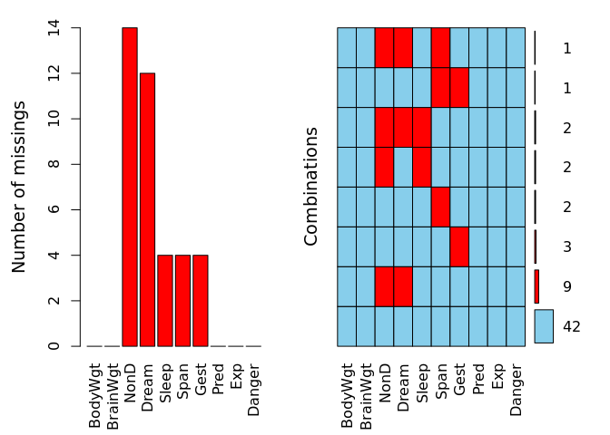

```r
data <- as.data.table(VIM::sleep)
a <- aggr(sleep, plot = FALSE)
plot(a, numbers = TRUE, prop = FALSE)
```

The left plot shows the amount of missings for each column in the dataset sleep and the right plot shows how often each combination of missings occur. For example, there are 9 rows wich contain a missing in both NonD and Dream.

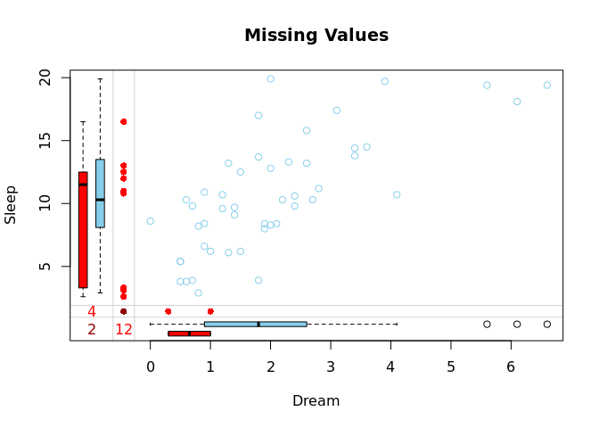

```r
dataDS <- sleep[, c("Dream", "Sleep")]
marginplot(dataDS, main = "Missing Values")
```

The **red** boxplot on the left shows the distrubution of all values of Sleep where Dream contains a missing value. The **blue** boxplot on the left shows the distribution of the values of Sleep where Dream is observed.

## Basic Usage

### Default Imputation

In the basic usage, the `vimpute()` function performs imputation using the default settings. It uses the “ranger” method for all variables, applies predictive mean matching, and performs sequential imputation with a convergence threshold of 0.005.

```r
result <- vimpute(
  data = data,
  pred_history = TRUE)
```

```r
print(head(result$data, 3))
```

```
#>     BodyWgt BrainWgt  NonD Dream Sleep  Span  Gest  Pred   Exp Danger NonD_imp
#>       <num>    <num> <num> <num> <num> <num> <num> <num> <num>  <num>   <lgcl>
#> 1: 6654.000   5712.0   3.3   1.3   3.3  38.6   645     3     5      3     TRUE
#> 2:    1.000      6.6   6.3   2.0   8.3   4.5    42     3     1      3    FALSE
#> 3:    3.385     44.5  10.6   2.3  12.5  14.0    60     1     1      1     TRUE
#>    Dream_imp Sleep_imp Span_imp Gest_imp
#>       <lgcl>    <lgcl>   <lgcl>   <lgcl>
#> 1:      TRUE     FALSE    FALSE    FALSE
#> 2:     FALSE     FALSE    FALSE    FALSE
#> 3:      TRUE     FALSE    FALSE    FALSE
```

Results and information about missing/imputed values can be shown in the plot margins:

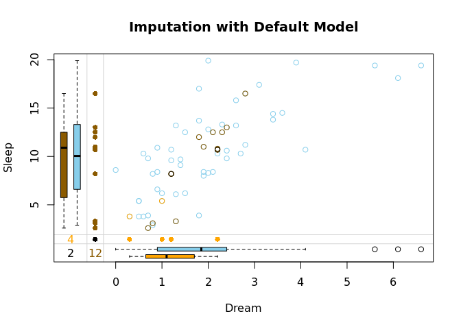

```r
dataDS <- as.data.frame(result$data[, c("Dream", "Sleep", "Dream_imp", "Sleep_imp")])
marginplot(dataDS, delimiter = "_imp", main = "Imputation with Default Model")
```

The default output are the imputed dataset and the prediction history.

In this plot three differnt colors are used in the top-right. These colors represent the structure of missings.

- **brown** points represent values where `Dream` was missing initially
- **beige** points represent values where `Sleep` was missing initially
- **black** points represent values where both `Dream` and `Sleep` were missing initially

## Advanced Options

#### Parameter `method`

*(default: “ranger” for all variables)*

- **`"robust"`**: Robust regression models
  - `lmrob` for numeric variables: Implements MM-estimation for resistance to outliers
  - `glmrob` for binary factors: Uses robust estimators to reduce outlier influence
- **`"regularized"`**: Regularized regression (`glmnet`)
  - Uses elastic net regularization
  - Automatically handles multicollinearity
- **`"ranger"`**: Random Forest
  - Fast implementation of random forests
  - Handles non-linear relationships well
- **`"xgboost"`**: Gradient Boosted Trees
  - State-of-the-art tree boosting
  - Handles mixed data types well

```r
result_mixed <- vimpute(
  data = data,
  method = list(NonD = "robust", Dream = "ranger", Sleep = "xgboost", Span = "ranger" , Gest = "regularized"),
  pred_history = TRUE
  )
```

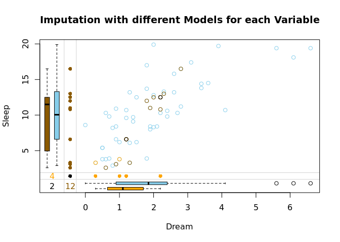

```r
dataDS <- as.data.frame(result_mixed$data[, c("Dream", "Sleep", "Dream_imp", "Sleep_imp")])
marginplot(dataDS, delimiter = "_imp", main = "Imputation with different Models for each Variable")
```

The side-by-side margin plots compare the performance of two imputation methods: xgboost (left) and regularized (right):

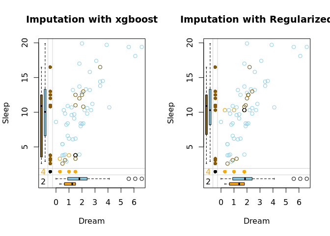

xgboost handles missing values with data-driven, uneven imputations that capture complex patterns but may be less stable, while regularized methods produce smoother, more conservative estimates that are less prone to overfitting. The key difference lies in flexibility (xgboost) versus robustness (regularization).

#### Parameter `pmm`

*(default: TRUE for all numeric variables)*

```r
result <- vimpute(
  data = data,
  method = list(NonD = "robust",
                Dream = "ranger",
                Sleep = "xgboost",
                Span = "ranger" ,
                Gest = "regularized"),
  pmm = list(NonD = FALSE, Dream = TRUE, Sleep = FALSE, Span = FALSE , Gest = TRUE)
  )
```

If TRUE, imputed values are restricted to actual observed values in the dataset, ensuring realism but potentially limiting variability. If FALSE, raw model predictions are used, allowing greater flexibility but risking implausible or extreme imputations.

#### Parameter `formula`

*(default: FALSE)*

Specifies custom model formulas for imputation of each variable, offering precise control over the imputation models.

**Key Features:**

1. **Variable-Specific Models**
   - Each formula specifies which predictors should be used for imputing a particular variable
   - Enables different predictor sets for different target variables
   - Example:

     ```r
     formula = list(
       income ~ education + age,
       blood_pressure ~ weight + age
     )
     ```

2. **Transformations Support**
   - Handles common transformations on both sides of the formula:
     - Response transformations: `log(y)`, `sqrt(y)`, `exp(y)`, `I(1/y)`
     - Predictor transformations: `log(x1)`, `poly(x2, 2)`, etc.
   - Example with transformations:

     ```r
     formula = list(
       log(income) ~ poly(age, 2) + education,
       sqrt(blood_pressure) ~ weight + I(1/age)
     )
     ```

3. **Interaction Terms**
   - Supports interaction terms using `:` or `*` syntax (on the right side)
   - Example:

     ```r
     formula = list(
       price ~ sqft * neighborhood + year_built
     )
     ```

**Example Demonstration:**

```r
result <- vimpute(
  data = data,
  method = setNames(as.list(rep("regularized", ncol(data))), names(data))
  formula = list(
    NonD ~ Dream + Sleep,              # Linear combination
    Span ~ Dream:Sleep + Gest,         # With interaction term
    log(Gest) ~ Sleep + exp(Span)      # With transformations
  )
)
```

**Interpreting the Example:**

1. For `NonD`:
   - Uses linear combination of `Dream` and `Sleep` variables
   - Model: `NonD = β₀ + β₁*Dream + β₂*Sleep + ε`
2. For `Span`:
   - Includes interaction between `Dream` and `Sleep`
   - Plus main effect of `Gest`
   - Model: `Span = β₀ + β₁*Dream*Sleep + β₂*Gest + ε`
3. For `Gest`:
   - Uses log-transformed response
   - Predictors include `Sleep` and exponential of `Span`
   - Model: `log(Gest) = β₀ + β₁*Sleep + β₂*exp(Span) + ε`
4. For `Sleep` and `Dream` all other variables are used as predictors

**Notes:**

- Only works with methods `"robust"` and `"regularized"`
- All model.matrix-compatible functions work for predictors (for more information see ?model.matrix)
- Response transformations (left side) are automatically back-transformed

#### Parameter `tune`

*(default: FALSE)*

```r
result <- vimpute(
  data = data,
  tune = TRUE
  )
```

Whether to perform hyperparameter tuning (only possible if seq = TRUE):

- When TRUE:
  - Conducts randomized parameter search (after half of the iterations)
  - Uses best performing configuration
- When FALSE:
  - Uses default model parameters
  - Recommended: TRUE for optimal performance

#### Parameters `nseq` and `eps`

*(default: 10 and default: 0.005)*

```r
result <- vimpute(
  data = data,
  nseq = 20,
  eps = 0.01
  )
```

`nseq` describes the number of sequential imputation iterations. Higher values:

- Allow more refinement
- Increase computation time

`eps` describes the convergence threshold for sequential imputation:

- Stops early if changes between iterations < eps
- Smaller values: Require more precise convergence but may need more iterations

#### Parameter `imp_var`

*(default: TRUE)*

```r
result <- vimpute(
  data = data,
  imp_var = TRUE
  )
```

Creating indicator variables for imputed values adds “_imp” columns (TRUE/FALSE) to mark which data points were imputed. This is particularly useful for tracking imputation effects and conducting diagnostic analyses.

#### Parameter `pred_history`

*(default: TRUE)*

```r
print(tail(result$pred_history, 9))
```

```
#>    iteration variable index predicted_values
#>        <int>   <char> <int>            <num>
#> 1:        10    Sleep    62             10.7
#> 2:        10     Span     4              7.0
#> 3:        10     Span    13              6.0
#> 4:        10     Span    35              6.0
#> 5:        10     Span    36              7.0
#> 6:        10     Gest    13             42.0
#> 7:        10     Gest    19            230.0
#> 8:        10     Gest    20             90.0
#> 9:        10     Gest    56             33.0
```

When enabled (TRUE), this option saves prediction trajectories in `$pred_history`, allowing users to track how imputed values evolve across iterations. This feature is particularly useful for diagnosing convergence issues.

## Performance

In order to validate the performance of vimpute() the iris dataset is used. Firstly, some values are randomly set to `NA`.

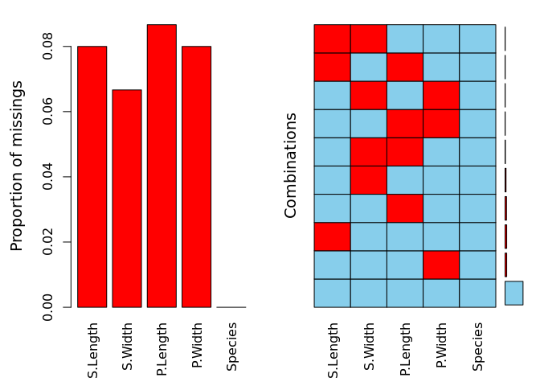

```r
library(reactable)

data(iris)
df <- as.data.table(iris)
colnames(df) <- c("S.Length","S.Width","P.Length","P.Width","Species")
# randomly produce some missing values in the data
set.seed(1)
nbr_missing <- 50
y <- data.frame(row=sample(nrow(iris),size = nbr_missing,replace = T),
                col=sample(ncol(iris)-1,size = nbr_missing,replace = T))
y<-y[!duplicated(y),]
df[as.matrix(y)]<-NA

aggr(df)
```

```r
sapply(df, function(x)sum(is.na(x)))
```

```
#> S.Length  S.Width P.Length  P.Width  Species
#>       12       10       13       12        0
```

For default model:

| True | Imputed | True | Imputed | True | Imputed | True | Imputed |
| --- | --- | --- | --- | --- | --- | --- | --- |
| 5.1 | 5.3 | 3.8 | 3.5 | 1.1 | 1.4 | 0.3 | 0.2 |
| 5.1 | 5.2 | 4.1 | 3.5 | 1.9 | 1.5 | 0.2 | 0.4 |
| 7 | 6.4 | 3.4 | 3.5 | 4.1 | 3.7 | 0.2 | 0.3 |
| 5.6 | 5.6 | 3.5 | 3.4 | 3.9 | 4.1 | 0.2 | 0.2 |
| 5.4 | 6 | 2.8 | 2.8 | 4.7 | 4.6 | 0.3 | 0.3 |

For xgboost model:

| True | Imputed | True | Imputed | True | Imputed | True | Imputed |
| --- | --- | --- | --- | --- | --- | --- | --- |
| 5.1 | 5.4 | 3.8 | 3.6 | 1.1 | 1.4 | 0.3 | 0.2 |
| 5.1 | 5.2 | 4.1 | 3.6 | 1.9 | 1.5 | 0.2 | 0.4 |
| 7 | 6.3 | 3.4 | 3.6 | 4.1 | 3.7 | 0.2 | 0.3 |
| 5.6 | 6 | 3.5 | 2.6 | 3.9 | 4.4 | 0.2 | 0.2 |
| 5.4 | 6.1 | 2.8 | 2.7 | 4.7 | 4.7 | 0.3 | 0.2 |